# Tugas MPDW 4

Karimatu Ain G1401211001 P2

2023-09-21

#Latihan MA(2)

Bangkitkan model MA(2) dengan
$$\theta =
0.4$$
dan
$$\theta = 0.6$$
sebanyak 300 data (Manual dan arima.sim)

$$y_t = e_t+0.4e_{t-1}+0.6e_{t-2}$$

```r
set.seed(001)
whitenoise<-rnorm(300)
ma <- whitenoise[c(1,2)]
```

Data dibangkitkan dengan cara manual:

```r
for(i in 3:300){
   ma[i] <- whitenoise[i] + 0.4 * whitenoise[i - 1] + 0.6*whitenoise[i-2]
}

ma
```

```
##   [1] -0.626453811  0.183643324 -1.138043569  1.371215352  0.466242925
##   [6]  0.268503206  0.356946362  0.441015296  1.163568665  0.367918977
##  [11]  1.735094625  0.811322671  0.441765415 -2.229290178 -0.133693385
##  [16] -0.923781174  0.640794844  0.910399940  1.189041522  1.488691526
##  [21]  1.649270617  1.506068042  0.938805927 -1.490243922 -0.131175940
##  [26] -1.001809458  0.193648446 -1.566747830 -1.159928313 -0.655769892
##  [31]  1.238966143  0.691449029  1.161764252  0.039590968 -1.165978606
##  [36] -0.998101410 -1.386523513 -0.466026116  0.839726041  1.167597859
##  [41]  0.800761926  0.138734330  0.496904546  0.683431541 -0.047912390
##  [46] -0.648999516 -0.331669517  0.489868615  0.413816135  1.297288996
##  [51]  0.683141244  0.075880595  0.335172662 -1.360131055  1.185950278
##  [56]  1.875991522  1.284752704 -0.002783278 -0.068267109 -0.533647529
##  [61]  2.689427695  0.840374339  2.115014018  0.280353902 -0.318228728
##  [66] -0.091715689 -2.175405634  0.856846790 -0.343499894  3.113245923
##  [71]  1.436506200  0.783824383  0.612053498 -1.115774949 -1.260836641
```

[output cut: 45 more lines]

Data dibangkitkan dengan arima.sim:

```r
ma2 <- arima.sim(list(order=c(0,0,2), ma=c(0.4,0.6)), n=300)
ma2
```

```
## Time Series:
## Start = 1
## End = 300
## Frequency = 1
##   [1]  2.088622348 -0.223476041  2.683494891  1.943691551  1.680337993
##   [6]  1.507734825 -0.747880673  0.253519660  0.558085972  0.710327372
##  [11]  0.211661961 -0.777989524 -0.570717309  0.661323380 -0.077863800
##  [16]  0.326896793 -1.632929007 -0.095949232  0.729142652  2.316789319
##  [21]  2.198260047 -0.645683092  0.222935627 -0.472925869  0.118271658
##  [26]  0.302810719 -1.007880337  0.435910075 -0.573830278 -1.292384127
##  [31] -1.191344239  0.276005316 -0.008977847  1.417698454  1.039116838
##  [36]  0.822682986  0.217388560 -0.667985209  0.316317639 -1.085439031
##  [41]  0.264581413 -0.829089478 -2.232962597 -2.488505819 -1.006454468
##  [46] -0.670181493  1.276383233  2.094020379  2.710840896  2.399305643
##  [51]  1.535198792  0.365547744  1.728750036  1.111711771  0.011651780
```

[output cut: 49 more lines]

### Plot Time Series

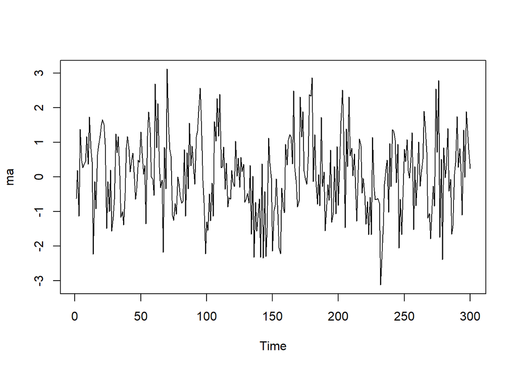

```r
ts.plot(ma)
```

Berdasarkan plot time series, terlihat bahwa data MA(2) yang dibangkitkan stasioner dalam rataan

### Plot ACF

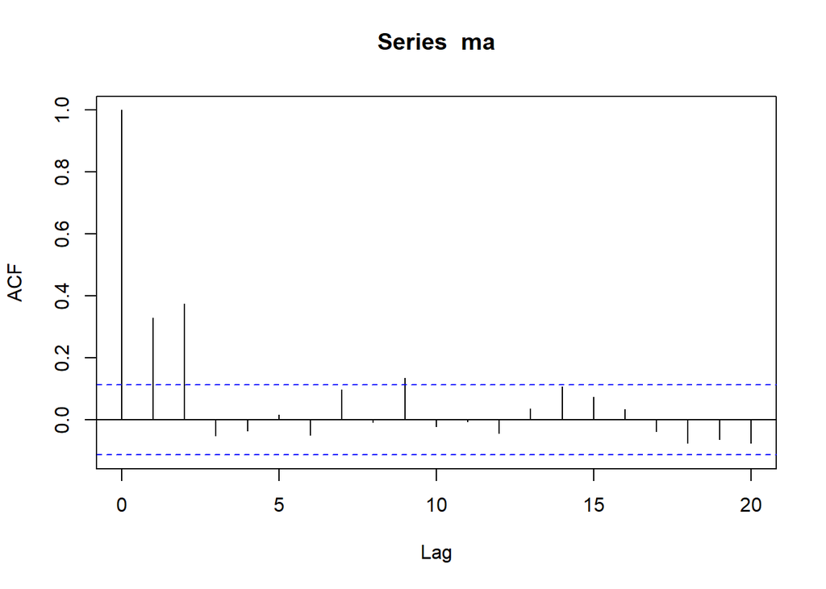

```r
acf(ma,lag.max = 20)
```

### Plot PACF

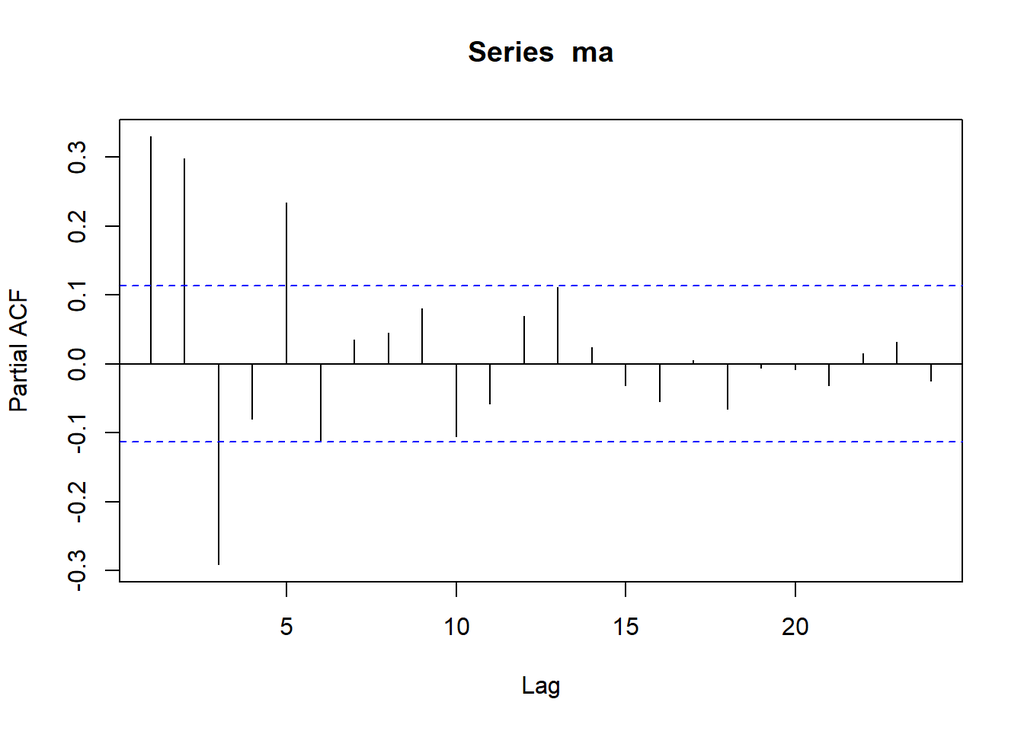

```r
pacf(ma)
```

Berdasarkan plot PACF tersebut, terlihat bahwa plot PACF cenderung *tails off* dan membentuk gelombang sinus

### Plot EACF

```r
TSA::eacf(ma)
```

```
## AR/MA
##   0 1 2 3 4 5 6 7 8 9 10 11 12 13
## 0 x x o o o o o o x o o  o  o  o
## 1 x x x o o o o o o o o  o  o  o
## 2 x x o o o o o o x o o  o  o  o
## 3 x x o o o o o o x o o  o  o  o
## 4 x x x o x x o o x o o  o  o  o
## 5 x o x x x x o o o o o  o  o  o
## 6 x o o x x x o o o o o  o  o  o
## 7 x o x x o o x x o o o  o  o  o
```

Berdasarkan pola segitiga nol pada plot EACF, terlihat bahwa segitiga nol berada pada ordo AR(0) dan ordo MA(2)

### Scatterplot Antar Lag

```r
#Yt
yt_ma <- ma[-1]
yt_ma
```

```
##   [1]  0.183643324 -1.138043569  1.371215352  0.466242925  0.268503206
##   [6]  0.356946362  0.441015296  1.163568665  0.367918977  1.735094625
##  [11]  0.811322671  0.441765415 -2.229290178 -0.133693385 -0.923781174
##  [16]  0.640794844  0.910399940  1.189041522  1.488691526  1.649270617
##  [21]  1.506068042  0.938805927 -1.490243922 -0.131175940 -1.001809458
##  [26]  0.193648446 -1.566747830 -1.159928313 -0.655769892  1.238966143
##  [31]  0.691449029  1.161764252  0.039590968 -1.165978606 -0.998101410
##  [36] -1.386523513 -0.466026116  0.839726041  1.167597859  0.800761926
##  [41]  0.138734330  0.496904546  0.683431541 -0.047912390 -0.648999516
##  [46] -0.331669517  0.489868615  0.413816135  1.297288996  0.683141244
##  [51]  0.075880595  0.335172662 -1.360131055  1.185950278  1.875991522
##  [56]  1.284752704 -0.002783278 -0.068267109 -0.533647529  2.689427695
##  [61]  0.840374339  2.115014018  0.280353902 -0.318228728 -0.091715689
##  [66] -2.175405634  0.856846790 -0.343499894  3.113245923  1.436506200
##  [71]  0.783824383  0.612053498 -1.115774949 -1.260836641 -0.770465704
```

[output cut: 45 more lines]

```r
#Yt-1
yt_1_ma <- ma[-300]
yt_1_ma
```

```
##   [1] -0.626453811  0.183643324 -1.138043569  1.371215352  0.466242925
##   [6]  0.268503206  0.356946362  0.441015296  1.163568665  0.367918977
##  [11]  1.735094625  0.811322671  0.441765415 -2.229290178 -0.133693385
##  [16] -0.923781174  0.640794844  0.910399940  1.189041522  1.488691526
##  [21]  1.649270617  1.506068042  0.938805927 -1.490243922 -0.131175940
##  [26] -1.001809458  0.193648446 -1.566747830 -1.159928313 -0.655769892
##  [31]  1.238966143  0.691449029  1.161764252  0.039590968 -1.165978606
##  [36] -0.998101410 -1.386523513 -0.466026116  0.839726041  1.167597859
##  [41]  0.800761926  0.138734330  0.496904546  0.683431541 -0.047912390
##  [46] -0.648999516 -0.331669517  0.489868615  0.413816135  1.297288996
##  [51]  0.683141244  0.075880595  0.335172662 -1.360131055  1.185950278
##  [56]  1.875991522  1.284752704 -0.002783278 -0.068267109 -0.533647529
##  [61]  2.689427695  0.840374339  2.115014018  0.280353902 -0.318228728
##  [66] -0.091715689 -2.175405634  0.856846790 -0.343499894  3.113245923
##  [71]  1.436506200  0.783824383  0.612053498 -1.115774949 -1.260836641
```

[output cut: 45 more lines]

```r
#Yt-2
yt_2_ma <- ma[-c(299,300)]
yt_2_ma
```

```
##   [1] -0.626453811  0.183643324 -1.138043569  1.371215352  0.466242925
##   [6]  0.268503206  0.356946362  0.441015296  1.163568665  0.367918977
##  [11]  1.735094625  0.811322671  0.441765415 -2.229290178 -0.133693385
##  [16] -0.923781174  0.640794844  0.910399940  1.189041522  1.488691526
##  [21]  1.649270617  1.506068042  0.938805927 -1.490243922 -0.131175940
##  [26] -1.001809458  0.193648446 -1.566747830 -1.159928313 -0.655769892
##  [31]  1.238966143  0.691449029  1.161764252  0.039590968 -1.165978606
##  [36] -0.998101410 -1.386523513 -0.466026116  0.839726041  1.167597859
##  [41]  0.800761926  0.138734330  0.496904546  0.683431541 -0.047912390
##  [46] -0.648999516 -0.331669517  0.489868615  0.413816135  1.297288996
##  [51]  0.683141244  0.075880595  0.335172662 -1.360131055  1.185950278
##  [56]  1.875991522  1.284752704 -0.002783278 -0.068267109 -0.533647529
##  [61]  2.689427695  0.840374339  2.115014018  0.280353902 -0.318228728
##  [66] -0.091715689 -2.175405634  0.856846790 -0.343499894  3.113245923
##  [71]  1.436506200  0.783824383  0.612053498 -1.115774949 -1.260836641
```

[output cut: 45 more lines]

```r
#Yt-3
yt_3_ma <- ma[-c(298,299,300)]
yt_3_ma
```

```
##   [1] -0.626453811  0.183643324 -1.138043569  1.371215352  0.466242925
##   [6]  0.268503206  0.356946362  0.441015296  1.163568665  0.367918977
##  [11]  1.735094625  0.811322671  0.441765415 -2.229290178 -0.133693385
##  [16] -0.923781174  0.640794844  0.910399940  1.189041522  1.488691526
##  [21]  1.649270617  1.506068042  0.938805927 -1.490243922 -0.131175940
##  [26] -1.001809458  0.193648446 -1.566747830 -1.159928313 -0.655769892
##  [31]  1.238966143  0.691449029  1.161764252  0.039590968 -1.165978606
##  [36] -0.998101410 -1.386523513 -0.466026116  0.839726041  1.167597859
##  [41]  0.800761926  0.138734330  0.496904546  0.683431541 -0.047912390
##  [46] -0.648999516 -0.331669517  0.489868615  0.413816135  1.297288996
##  [51]  0.683141244  0.075880595  0.335172662 -1.360131055  1.185950278
##  [56]  1.875991522  1.284752704 -0.002783278 -0.068267109 -0.533647529
##  [61]  2.689427695  0.840374339  2.115014018  0.280353902 -0.318228728
##  [66] -0.091715689 -2.175405634  0.856846790 -0.343499894  3.113245923
##  [71]  1.436506200  0.783824383  0.612053498 -1.115774949 -1.260836641
```

[output cut: 45 more lines]

#### Korelasi antara $Y_t$ dengan $Y_{t-1}$

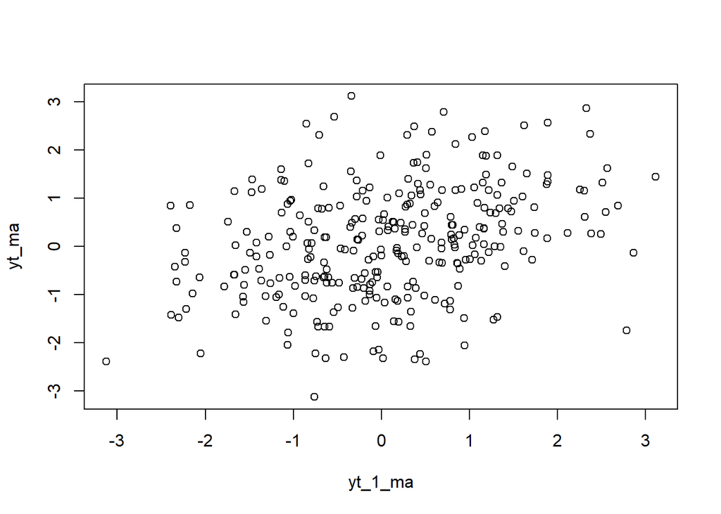

```r
plot(y=yt_ma,x=yt_1_ma)
```

```r
cor(yt_ma,yt_1_ma)
```

```
## [1] 0.3299581
```

Berdasarkan scatterplot dan nilai korelasi tersebut, terlihat bahwa terdapat hubungan positif antara $Y_t$ dengan $Y_{t-1}$. Hal ini sesuai dengan teori yang ada.

$$\rho_1=\frac{\theta_2}{1+(-\theta_1)^2+(-\theta_2)^2}=\frac{(0.6)}{1+(-0.4)^2+(-0.6)^2}=0.4$$

#### Plot dan Korelasi antara $Y_t$ dengan $Y_{t-2}$

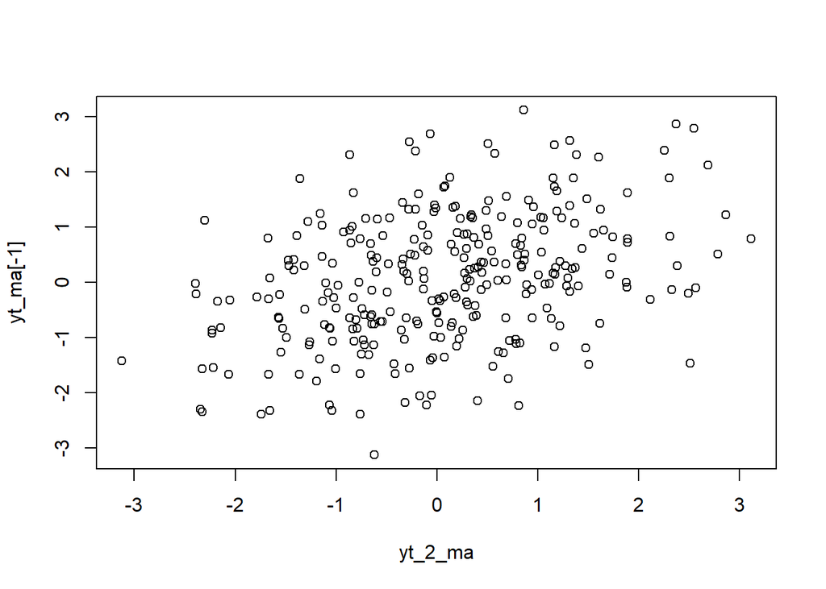

```r
plot(y=yt_ma[-1],x=yt_2_ma)
```

```r
cor(yt_ma[-1],yt_2_ma)
```

```
## [1] 0.3745449
```

Berdasarkan scatterplot dan nilai korelasi tersebut, terlihat bahwa terdapat hubungan positif antara $Y_t$ dengan $Y_{t-2}$.

#### Plot dan Korelasi antara $Y_t$ dengan $Y_{t-3}$

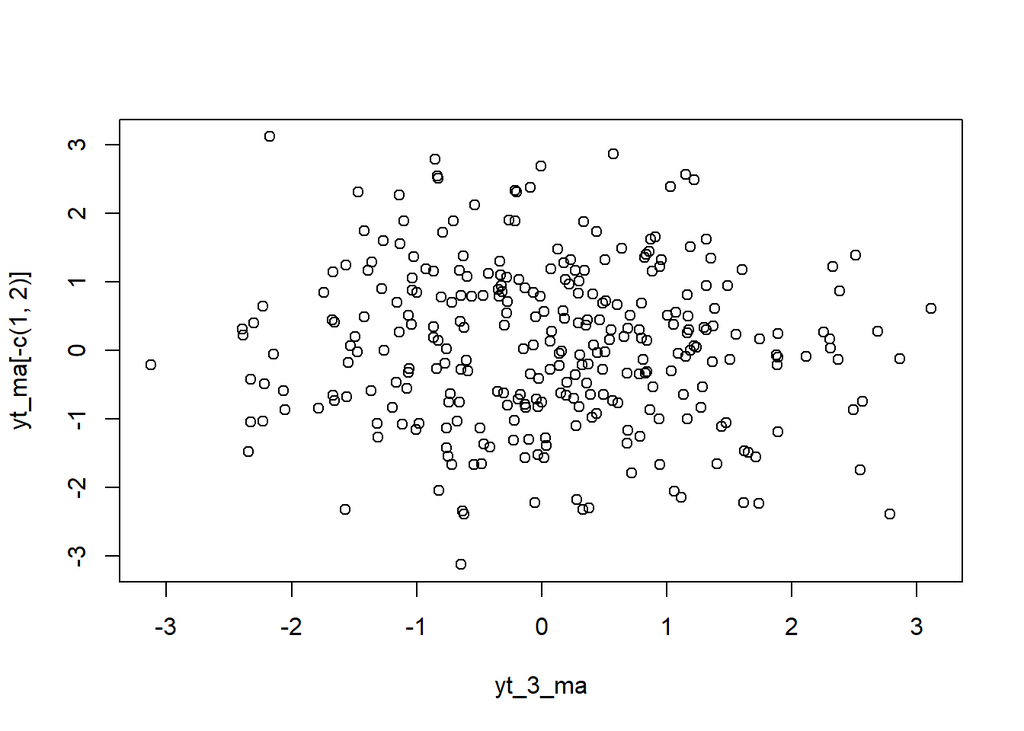

```r
plot(y=yt_ma[-c(1,2)],x=yt_3_ma)
```

```r
cor(yt_ma[-c(1,2)],yt_3_ma)
```

```
## [1] -0.05214203
```

Korelasi antara $Y_t$ dengan $Y_{t-3}$ hasil simulasi mendekati teori yang ada yaitu 0. Cenderung tidak ada hubungan

# AR (2)

Bangkitkan model R(2) dengan
$$\phi_1=0.5$$
dan
$$\phi_2=0.2$$
sebanyal 300 data (manual dan arima.sim)

```r
set.seed(001)
```

Nilai-nilai selanjutnya dapat dicari melalui *loop*. Bentuk loop dapat dilihat dari rumus AR(2) yang hendak dibangkitkan:

$$Y_t = e_t+0.5Y_{t-1}+0.2Y_{t-2}$$

```r
n<-length(whitenoise)
n
```

```
## [1] 300
```

```r
ar <- c(1:n)
for (i in 3:n) {ar[i]<-whitenoise[i]+0.5*ar[i-1]+0.2*ar[i-2]}
ar
```

```
##   [1]  1.0000000000  2.0000000000  0.3643713876  2.1774664959  1.4911152973
##   [6]  0.3605825637  0.9659433937  1.2934129147  1.4156764878  0.6611324397
##  [11]  2.1254826858  1.5848110673  0.5962614903 -1.5996069286  0.4443797519
##  [16] -0.1426651188  0.0013531279  0.9159797509  1.2794816961  1.4168381194
##  [21]  1.8832927706  2.0071503099  1.4547986924 -0.8605222877  0.4805243425
##  [26]  0.0120289742 -0.0536761511 -1.4951846646 -1.2364776176 -0.4993341815
##  [31]  0.8617169372  0.2282039050  0.6741169515  0.3288942162 -1.0777890585
##  [36] -0.8881102493 -1.0539028900 -0.7638868916  0.5073013482  0.8640490442
##  [41]  0.3689611955  0.1039287265  0.8227199777  0.9888089328 -0.0298072326
##  [46] -0.5246369867  0.0963020223  0.7117565383  0.2627924615  1.1548552648
##  [51]  1.0280920051  0.1329906623  0.6132334236 -0.7961482518  1.1575962605
##  [56]  2.3999683784  1.0642819648 -0.0319999682  0.7665760363  0.2418334206
##  [61]  2.6758496781  1.3470515204  1.8984350583  1.2466299920  0.2597287988
##  [66]  0.5679826973 -1.4690215205  0.8446406408  0.2817693545  2.4824244758
##  [71]  1.7730756377  0.6730762831  1.3018796226 -0.1485425637 -1.0675287576
```

[output cut: 45 more lines]

Selain menggunakan cara di atas, pembangkitan proses AR dapat dilakukan dengan fungsi `arima.sim()` sebagai berikut.

```r
ar2 <- arima.sim(list(order=c(2,0,0), ar=c(0.5,0.2)), n=300)
ar2
```

```
## Time Series:
## Start = 1
## End = 300
## Frequency = 1
##   [1]  0.0092051427 -0.0558288921 -1.4968258014 -1.2377287342 -0.5002879672
##   [6]  0.8609898211  0.2276495898  0.6736943707  0.3285720627 -1.0780346514
##  [11] -0.8882974764 -1.0540456222 -0.7639957031  0.5072183960  0.8639858058
##  [16]  0.3689129859  0.1038919740  0.8226919596  0.9887875732 -0.0298235160
##  [21] -0.5246494003  0.0962925588  0.7117493238  0.2627869615  1.1548510720
##  [26]  1.0280888087  0.1329882255  0.6132315659 -0.7961496680  1.1575951809
##  [31]  2.3999675553  1.0642813374 -0.0320004466  0.7665756716  0.2418331426
##  [36]  2.6758494661  1.3470513589  1.8984349351  1.2466298981  0.2597287272
##  [41]  0.5679826427 -1.4690215621  0.8446406091  0.2817693303  2.4824244573
##  [46]  1.7730756236  0.6730762724  1.3018796144 -0.1485425700 -1.0675287623
##  [51] -0.2720266596 -0.7928109555 -0.4497054581 -0.3090735960 -0.8339988358
```

[output cut: 49 more lines]

### Plot Time Series

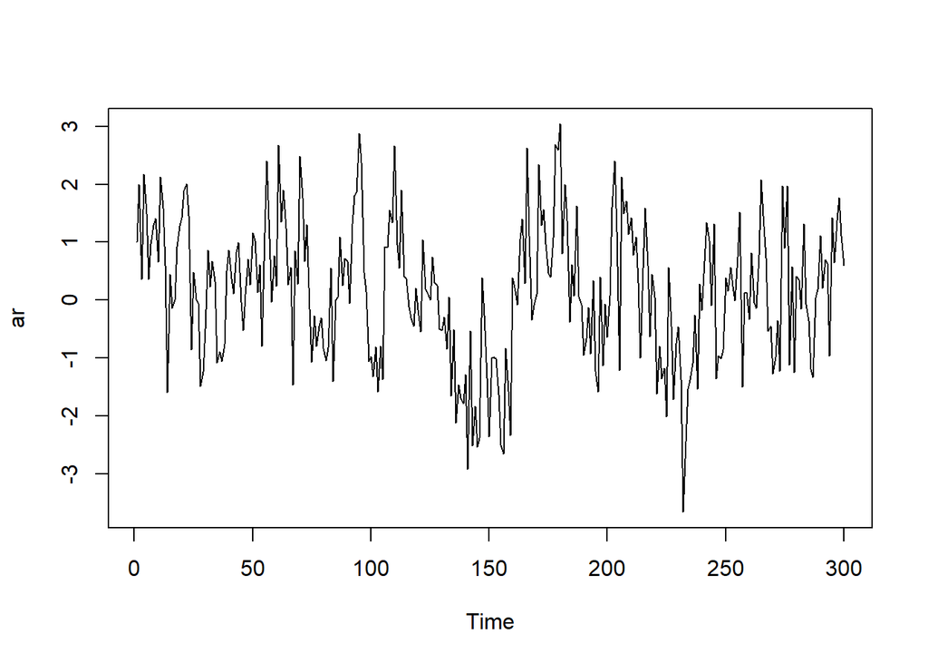

```r
ts.plot(ar)
```

Berdasarkan plot time series tersebut terlihat bahwa data cenderung stasioner pada rataan

### Plot ACF

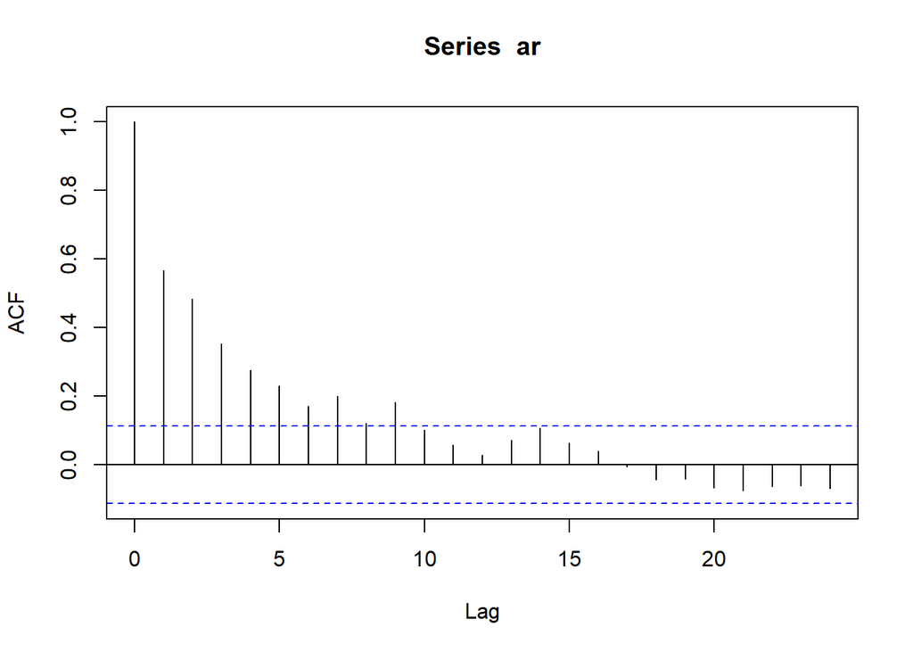

```r
acf(ar)
```

### Plot PACF

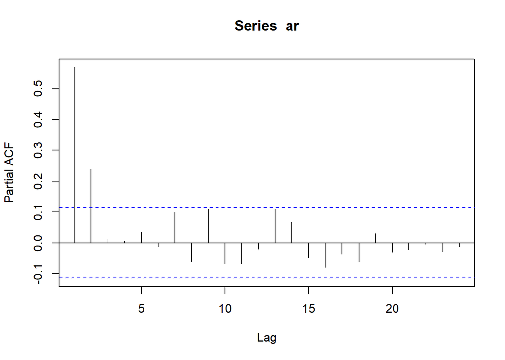

```r
pacf(ar)
```

### Plot EACF

```r
TSA::eacf(ar)
```

```
## AR/MA
##   0 1 2 3 4 5 6 7 8 9 10 11 12 13
## 0 x x x x x x x x x o o  o  o  o
## 1 x o o o o o x o x o o  o  o  o
## 2 o o o o o o o o x o o  o  o  o
## 3 x o x o o o o o x o o  o  o  o
## 4 x x o o o o o o o o o  o  o  o
## 5 x x x o o o o o o o o  o  o  o
## 6 x x x o o o o o o o o  o  o  o
## 7 x x x x o o o o o o o  o  o  x
```

Berdasarkan pola segitiga nol pada plot EACF, terlihat bahwa segitiga nol berada pada ordo AR(1) dan ordo MA(1)

### Scatterplot Antar Lag

```r
#Yt
yt_ar <- ar[-1]
yt_ar
```

```
##   [1]  2.0000000000  0.3643713876  2.1774664959  1.4911152973  0.3605825637
##   [6]  0.9659433937  1.2934129147  1.4156764878  0.6611324397  2.1254826858
##  [11]  1.5848110673  0.5962614903 -1.5996069286  0.4443797519 -0.1426651188
##  [16]  0.0013531279  0.9159797509  1.2794816961  1.4168381194  1.8832927706
##  [21]  2.0071503099  1.4547986924 -0.8605222877  0.4805243425  0.0120289742
##  [26] -0.0536761511 -1.4951846646 -1.2364776176 -0.4993341815  0.8617169372
##  [31]  0.2282039050  0.6741169515  0.3288942162 -1.0777890585 -0.8881102493
##  [36] -1.0539028900 -0.7638868916  0.5073013482  0.8640490442  0.3689611955
##  [41]  0.1039287265  0.8227199777  0.9888089328 -0.0298072326 -0.5246369867
##  [46]  0.0963020223  0.7117565383  0.2627924615  1.1548552648  1.0280920051
##  [51]  0.1329906623  0.6132334236 -0.7961482518  1.1575962605  2.3999683784
##  [56]  1.0642819648 -0.0319999682  0.7665760363  0.2418334206  2.6758496781
##  [61]  1.3470515204  1.8984350583  1.2466299920  0.2597287988  0.5679826973
##  [66] -1.4690215205  0.8446406408  0.2817693545  2.4824244758  1.7730756377
##  [71]  0.6730762831  1.3018796226 -0.1485425637 -1.0675287576 -0.2720266560
```

[output cut: 45 more lines]

```r
#Yt-1
yt_1_ar <- ar[-300]
yt_1_ar
```

```
##   [1]  1.0000000000  2.0000000000  0.3643713876  2.1774664959  1.4911152973
##   [6]  0.3605825637  0.9659433937  1.2934129147  1.4156764878  0.6611324397
##  [11]  2.1254826858  1.5848110673  0.5962614903 -1.5996069286  0.4443797519
##  [16] -0.1426651188  0.0013531279  0.9159797509  1.2794816961  1.4168381194
##  [21]  1.8832927706  2.0071503099  1.4547986924 -0.8605222877  0.4805243425
##  [26]  0.0120289742 -0.0536761511 -1.4951846646 -1.2364776176 -0.4993341815
##  [31]  0.8617169372  0.2282039050  0.6741169515  0.3288942162 -1.0777890585
##  [36] -0.8881102493 -1.0539028900 -0.7638868916  0.5073013482  0.8640490442
##  [41]  0.3689611955  0.1039287265  0.8227199777  0.9888089328 -0.0298072326
##  [46] -0.5246369867  0.0963020223  0.7117565383  0.2627924615  1.1548552648
##  [51]  1.0280920051  0.1329906623  0.6132334236 -0.7961482518  1.1575962605
##  [56]  2.3999683784  1.0642819648 -0.0319999682  0.7665760363  0.2418334206
##  [61]  2.6758496781  1.3470515204  1.8984350583  1.2466299920  0.2597287988
##  [66]  0.5679826973 -1.4690215205  0.8446406408  0.2817693545  2.4824244758
##  [71]  1.7730756377  0.6730762831  1.3018796226 -0.1485425637 -1.0675287576
```

[output cut: 45 more lines]

```r
#Yt-2
yt_2_ar<- ar[-c(299,300)]
yt_2_ar
```

```
##   [1]  1.0000000000  2.0000000000  0.3643713876  2.1774664959  1.4911152973
##   [6]  0.3605825637  0.9659433937  1.2934129147  1.4156764878  0.6611324397
##  [11]  2.1254826858  1.5848110673  0.5962614903 -1.5996069286  0.4443797519
##  [16] -0.1426651188  0.0013531279  0.9159797509  1.2794816961  1.4168381194
##  [21]  1.8832927706  2.0071503099  1.4547986924 -0.8605222877  0.4805243425
##  [26]  0.0120289742 -0.0536761511 -1.4951846646 -1.2364776176 -0.4993341815
##  [31]  0.8617169372  0.2282039050  0.6741169515  0.3288942162 -1.0777890585
##  [36] -0.8881102493 -1.0539028900 -0.7638868916  0.5073013482  0.8640490442
##  [41]  0.3689611955  0.1039287265  0.8227199777  0.9888089328 -0.0298072326
##  [46] -0.5246369867  0.0963020223  0.7117565383  0.2627924615  1.1548552648
##  [51]  1.0280920051  0.1329906623  0.6132334236 -0.7961482518  1.1575962605
##  [56]  2.3999683784  1.0642819648 -0.0319999682  0.7665760363  0.2418334206
##  [61]  2.6758496781  1.3470515204  1.8984350583  1.2466299920  0.2597287988
##  [66]  0.5679826973 -1.4690215205  0.8446406408  0.2817693545  2.4824244758
##  [71]  1.7730756377  0.6730762831  1.3018796226 -0.1485425637 -1.0675287576
```

[output cut: 45 more lines]

```r
#Yt-3
yt_3_ar <- ar[-c(298,299,300)]
yt_3_ar
```

```
##   [1]  1.0000000000  2.0000000000  0.3643713876  2.1774664959  1.4911152973
##   [6]  0.3605825637  0.9659433937  1.2934129147  1.4156764878  0.6611324397
##  [11]  2.1254826858  1.5848110673  0.5962614903 -1.5996069286  0.4443797519
##  [16] -0.1426651188  0.0013531279  0.9159797509  1.2794816961  1.4168381194
##  [21]  1.8832927706  2.0071503099  1.4547986924 -0.8605222877  0.4805243425
##  [26]  0.0120289742 -0.0536761511 -1.4951846646 -1.2364776176 -0.4993341815
##  [31]  0.8617169372  0.2282039050  0.6741169515  0.3288942162 -1.0777890585
##  [36] -0.8881102493 -1.0539028900 -0.7638868916  0.5073013482  0.8640490442
##  [41]  0.3689611955  0.1039287265  0.8227199777  0.9888089328 -0.0298072326
##  [46] -0.5246369867  0.0963020223  0.7117565383  0.2627924615  1.1548552648
##  [51]  1.0280920051  0.1329906623  0.6132334236 -0.7961482518  1.1575962605
##  [56]  2.3999683784  1.0642819648 -0.0319999682  0.7665760363  0.2418334206
##  [61]  2.6758496781  1.3470515204  1.8984350583  1.2466299920  0.2597287988
##  [66]  0.5679826973 -1.4690215205  0.8446406408  0.2817693545  2.4824244758
##  [71]  1.7730756377  0.6730762831  1.3018796226 -0.1485425637 -1.0675287576
```

[output cut: 45 more lines]

#### Korelasi antara $Y_t$ dengan $Y_{t-1}$

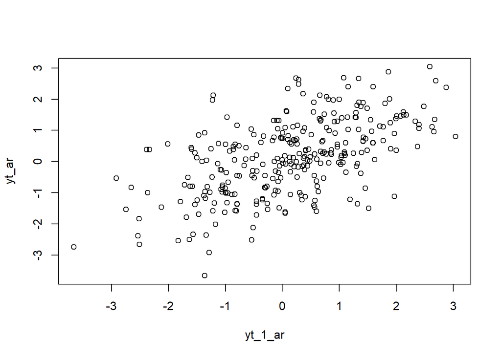

```r
plot(y=yt_ar,x=yt_1_ar)
```

```r
cor(yt_ar,yt_1_ar)
```

```
## [1] 0.5679937
```

Berdasarkan scatterplot tersebut, terlihat bahwa terdapat hubungan positif antara $Y_t$ dengan $Y_{t-1}$. Hal ini sesuai dengan teori yang ada. Selanjutnya, korelasi antara $Y_t$ dengan $Y_{t-1}$ dari hasil simulasi mendekati perhitungan teoritis yaitu $\rho_1=\phi^1=0.5$

#### Korelasi antara $Y_t$ dengan $Y_{t-2}$

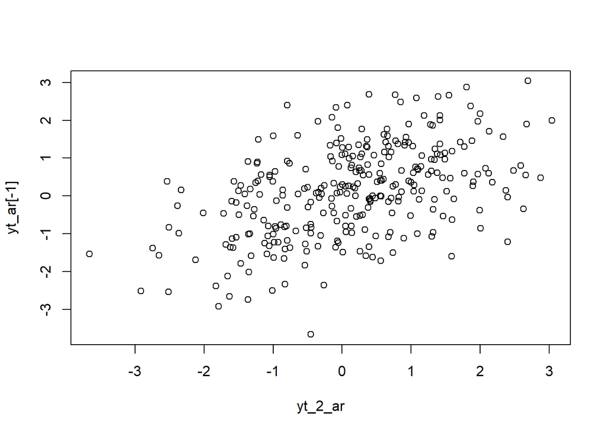

```r
plot(y=yt_ar[-1],x=yt_2_ar)
```

```r
cor(yt_ar[-1],yt_2_ar)
```

```
## [1] 0.4866758
```

#### Korelasi antara $Y_t$ dengan $Y_{t-3}$

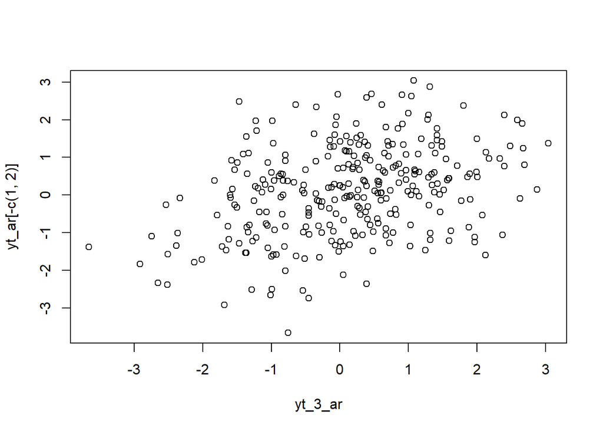

```r
plot(y=yt_ar[-c(1,2)],x=yt_3_ar)
```

```r
cor(yt_ar[-c(1,2)],yt_3_ar)
```

```
## [1] 0.3552017
```

# ARMA(2)

Bangkitkan model ARMA(2,2) denagna
$$\theta_1=0.4$$
,
$$\theta_2=0.6$$
,
$$\phi_1=0.5$$
, dan
$$\phi_2=0.2$$

```r
set.seed(001)
coefs <- c(0.4, 0.6, 0.5, 0.2)
e <- c(1, 2, 3, 4)

coefs %*% e
```

```
##      [,1]
## [1,]  3.9
```

Atau, dapat dilakukan perkalian *elementwise* yang dijumlahkan:

```r
coefs * e
```

```
## [1] 0.4 1.2 1.5 0.8
```

```r
sum(coefs * e)
```

```
## [1] 3.9
```

```r
set.seed(001)
n = length(whitenoise)
phi1 = 0.5
phi2= 0.2
theta1 = 0.4
theta2 = 0.6

y.arma=c(1:n)
for (i in 3:n){y.arma[i] = phi1*y.arma[i-1] + theta1*whitenoise[i-1]+whitenoise[i]+phi2*y.arma[i-2]+ theta2*whitenoise[i-2]+whitenoise[i]}

y.arma
```

```
##   [1]  1.00000000  2.00000000 -0.77367218  2.97966006  2.13084629  1.10938998
##   [7]  1.82523966  2.31383783  3.26131686  2.15595659  4.97711746  4.12091595
##  [13]  2.87640630 -2.18160372  0.47571693 -1.16717706  0.13615944  1.68888046
##  [19]  2.88193483  3.86133635  5.07530313  5.59812318  4.82749313  0.05377558
##  [25]  1.48103622 -0.30666497  0.18072770 -3.00846936 -3.10616751 -2.39260596
##  [31]  0.78010921  0.50019472  1.95555506  1.06360240 -1.62012595 -2.01043847
##  [37] -3.11005789 -2.48245615  0.07651176  1.47253826  1.38780981  0.87378521
##  [43]  1.90832249  2.36901302  0.82950292 -0.46794061 -0.03515727  1.14723478
##  [49]  0.86805586  2.84187161  2.67579410  1.37012557  1.89651396 -1.26721206
##  [55]  2.36467074  4.78528438  3.78310757  1.80169276  2.15892041  0.77109662
##  [61]  5.90837785  3.90954259  5.94120024  4.06086470  2.15717046  1.98783478
##  [67] -2.55501278  1.44246222  0.01998200  5.58434103  4.70818265  3.54483748
##  [73]  3.93683512  0.62751248 -1.41334678 -1.06019036 -2.33494983 -1.37975129
##  [79] -1.27371595 -2.06145038 -2.61400943 -2.57083208  0.15268338 -3.09483070
##  [85] -0.23156082 -0.74540741  2.19673167  0.96592666  2.17853362  1.78214689
```

[output cut: 35 more lines]

Pembangkitan ARMA(p,q) juga dapat dilakukan dengan fungsi `arima.sim` sebagai berikut.

```r
arma22 <- arima.sim(list(order=c(2,0,2), ar = c(0.5,0.2), ma = c(0.4,0.6)), n=300)
arma22
```

```
## Time Series:
## Start = 1
## End = 300
## Frequency = 1
##   [1] -1.51328469 -1.86968989 -1.89327178 -0.08160772  0.27199081  1.28143811
##   [7]  0.73470819 -0.54233689 -1.12232822 -2.05615500 -1.71856926 -0.43078959
##  [13]  0.60848921  1.01884861  0.76985648  1.08560251  1.38020409  0.85931016
##  [19]  0.05669638 -0.13145930  0.43547824  0.60526340  1.68701634  1.64770210
##  [25]  1.23713491  1.28328054 -0.47106380  1.20707448  2.38531600  2.71882560
##  [31]  1.83369272  1.39234437  0.52926320  3.23252817  2.56249107  4.04276518
##  [37]  2.81423471  1.89744166  1.41985208 -1.08599126  0.59782158 -0.26178736
##  [43]  3.10191656  2.93510701  2.87176120  2.63495550  0.77605504 -0.34581802
##  [49] -0.78816371 -1.54213888 -0.93004584 -0.96464235 -1.22745155 -1.56652656
##  [55] -1.74511227 -0.40304713 -1.68398519 -0.23123036 -0.79602345  1.10838990
##  [61]  0.71581649  1.46579137  1.10865494  0.63381652  1.68975832  2.28968018
```

[output cut: 39 more lines]

## Karakteristik ARMA(2,2)

### Plot Time Series

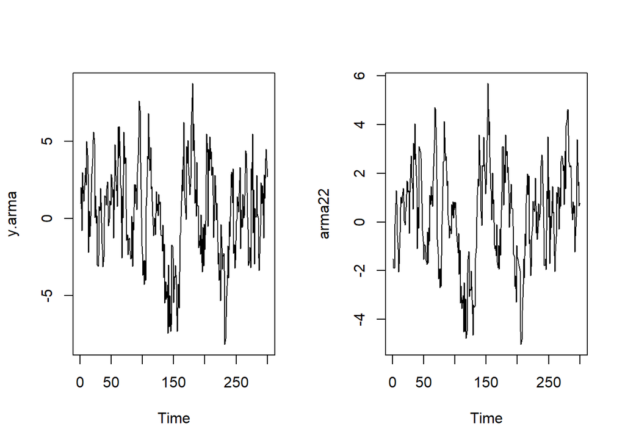

```r
par(mfrow = c(1, 2))
ts.plot(y.arma)
ts.plot(arma22)
```

Berdasarkan plot time series tersebut, terlihat bahwa model ARMA(2,2) cenderung stasioner dalam rataan

### Plot ACF

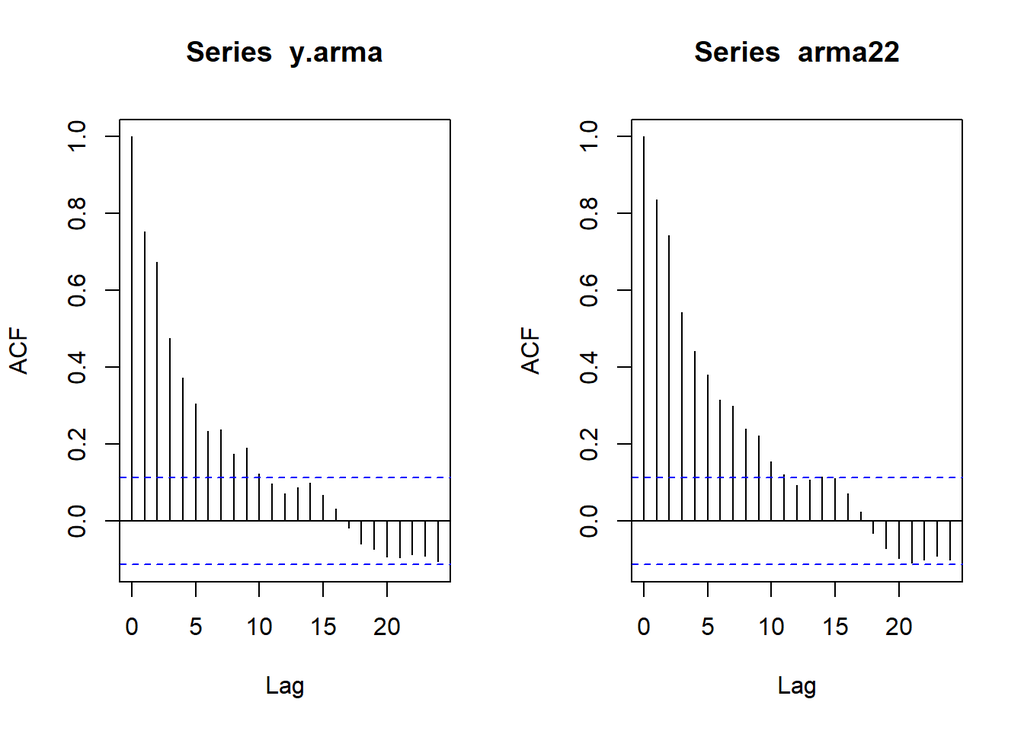

```r
par(mfrow = c(1, 2))
acf(y.arma)
acf(arma22)
```

### Plot PACF

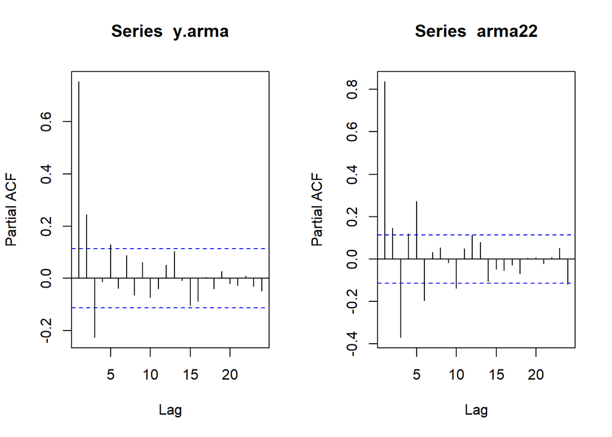

```r
par(mfrow = c(1, 2))
pacf(y.arma)
pacf(arma22)
```

```r
par(mfrow = c(1, 1))
```

### Plot EACF

```r
TSA::eacf(y.arma)
```

```
## AR/MA
##   0 1 2 3 4 5 6 7 8 9 10 11 12 13
## 0 x x x x x x x x x x o  o  o  o
## 1 x x x o o x x x x o o  o  o  o
## 2 x x x o o o o o x o o  o  o  o
## 3 o x o o o o o o x o o  o  o  o
## 4 o x o x x o o o o o o  o  o  o
## 5 x x o o o o o o o o o  o  o  o
## 6 x x x o o o o o o o o  o  o  o
## 7 x x x o o o o o o o o  o  o  x
```

```r
TSA::eacf(arma22)
```

```
## AR/MA
##   0 1 2 3 4 5 6 7 8 9 10 11 12 13
## 0 x x x x x x x x x x x  o  o  o
## 1 x x x o o x x x x o o  o  o  o
## 2 x x x x o o o o x o o  x  o  o
## 3 x x x x x o o o x o o  x  o  o
## 4 x x x x x x o o o o o  o  o  o
## 5 x x o o x o x o o o o  o  o  o
## 6 x x o o x o o o o o o  o  o  o
## 7 x x o o x o o o o o o  o  o  o
```

### Scatterplot Antar Lag

```r
#Yt
yt_arma <- arma22[-1]
yt_arma
```

```
##   [1] -1.86968989 -1.89327178 -0.08160772  0.27199081  1.28143811  0.73470819
##   [7] -0.54233689 -1.12232822 -2.05615500 -1.71856926 -0.43078959  0.60848921
##  [13]  1.01884861  0.76985648  1.08560251  1.38020409  0.85931016  0.05669638
##  [19] -0.13145930  0.43547824  0.60526340  1.68701634  1.64770210  1.23713491
##  [25]  1.28328054 -0.47106380  1.20707448  2.38531600  2.71882560  1.83369272
##  [31]  1.39234437  0.52926320  3.23252817  2.56249107  4.04276518  2.81423471
##  [37]  1.89744166  1.41985208 -1.08599126  0.59782158 -0.26178736  3.10191656
##  [43]  2.93510701  2.87176120  2.63495550  0.77605504 -0.34581802 -0.78816371
##  [49] -1.54213888 -0.93004584 -0.96464235 -1.22745155 -1.56652656 -1.74511227
##  [55] -0.40304713 -1.68398519 -0.23123036 -0.79602345  1.10838990  0.71581649
##  [61]  1.46579137  1.10865494  0.63381652  1.68975832  2.28968018  3.37188713
##  [67]  4.70704009  4.64124547  3.16093319  1.75990524 -0.70773485 -1.30909131
##  [73] -2.34058712 -1.92218300 -2.69550423 -1.91325908 -2.63365651 -0.09920940
##  [79]  0.45453560  2.46465550  2.50151441  4.12564306  2.83076961  2.53387975
##  [85]  2.69927627  1.50164379  1.68238721  0.27534432 -0.12739488 -0.65142379
```

[output cut: 35 more lines]

```r
#Yt-1
yt_1_arma <- arma22[-300]
yt_1_arma
```

```
##   [1] -1.51328469 -1.86968989 -1.89327178 -0.08160772  0.27199081  1.28143811
##   [7]  0.73470819 -0.54233689 -1.12232822 -2.05615500 -1.71856926 -0.43078959
##  [13]  0.60848921  1.01884861  0.76985648  1.08560251  1.38020409  0.85931016
##  [19]  0.05669638 -0.13145930  0.43547824  0.60526340  1.68701634  1.64770210
##  [25]  1.23713491  1.28328054 -0.47106380  1.20707448  2.38531600  2.71882560
##  [31]  1.83369272  1.39234437  0.52926320  3.23252817  2.56249107  4.04276518
##  [37]  2.81423471  1.89744166  1.41985208 -1.08599126  0.59782158 -0.26178736
##  [43]  3.10191656  2.93510701  2.87176120  2.63495550  0.77605504 -0.34581802
##  [49] -0.78816371 -1.54213888 -0.93004584 -0.96464235 -1.22745155 -1.56652656
##  [55] -1.74511227 -0.40304713 -1.68398519 -0.23123036 -0.79602345  1.10838990
##  [61]  0.71581649  1.46579137  1.10865494  0.63381652  1.68975832  2.28968018
##  [67]  3.37188713  4.70704009  4.64124547  3.16093319  1.75990524 -0.70773485
##  [73] -1.30909131 -2.34058712 -1.92218300 -2.69550423 -1.91325908 -2.63365651
##  [79] -0.09920940  0.45453560  2.46465550  2.50151441  4.12564306  2.83076961
##  [85]  2.53387975  2.69927627  1.50164379  1.68238721  0.27534432 -0.12739488
```

[output cut: 35 more lines]

```r
#Yt-2
yt_2_arma <- arma22[-c(299,300)]
yt_2_arma
```

```
##   [1] -1.51328469 -1.86968989 -1.89327178 -0.08160772  0.27199081  1.28143811
##   [7]  0.73470819 -0.54233689 -1.12232822 -2.05615500 -1.71856926 -0.43078959
##  [13]  0.60848921  1.01884861  0.76985648  1.08560251  1.38020409  0.85931016
##  [19]  0.05669638 -0.13145930  0.43547824  0.60526340  1.68701634  1.64770210
##  [25]  1.23713491  1.28328054 -0.47106380  1.20707448  2.38531600  2.71882560
##  [31]  1.83369272  1.39234437  0.52926320  3.23252817  2.56249107  4.04276518
##  [37]  2.81423471  1.89744166  1.41985208 -1.08599126  0.59782158 -0.26178736
##  [43]  3.10191656  2.93510701  2.87176120  2.63495550  0.77605504 -0.34581802
##  [49] -0.78816371 -1.54213888 -0.93004584 -0.96464235 -1.22745155 -1.56652656
##  [55] -1.74511227 -0.40304713 -1.68398519 -0.23123036 -0.79602345  1.10838990
##  [61]  0.71581649  1.46579137  1.10865494  0.63381652  1.68975832  2.28968018
##  [67]  3.37188713  4.70704009  4.64124547  3.16093319  1.75990524 -0.70773485
##  [73] -1.30909131 -2.34058712 -1.92218300 -2.69550423 -1.91325908 -2.63365651
##  [79] -0.09920940  0.45453560  2.46465550  2.50151441  4.12564306  2.83076961
##  [85]  2.53387975  2.69927627  1.50164379  1.68238721  0.27534432 -0.12739488
```

[output cut: 35 more lines]

```r
#Yt-3
yt_3_arma <- arma22[-c(298,299,300)]
yt_3_arma
```

```
##   [1] -1.51328469 -1.86968989 -1.89327178 -0.08160772  0.27199081  1.28143811
##   [7]  0.73470819 -0.54233689 -1.12232822 -2.05615500 -1.71856926 -0.43078959
##  [13]  0.60848921  1.01884861  0.76985648  1.08560251  1.38020409  0.85931016
##  [19]  0.05669638 -0.13145930  0.43547824  0.60526340  1.68701634  1.64770210
##  [25]  1.23713491  1.28328054 -0.47106380  1.20707448  2.38531600  2.71882560
##  [31]  1.83369272  1.39234437  0.52926320  3.23252817  2.56249107  4.04276518
##  [37]  2.81423471  1.89744166  1.41985208 -1.08599126  0.59782158 -0.26178736
##  [43]  3.10191656  2.93510701  2.87176120  2.63495550  0.77605504 -0.34581802
##  [49] -0.78816371 -1.54213888 -0.93004584 -0.96464235 -1.22745155 -1.56652656
##  [55] -1.74511227 -0.40304713 -1.68398519 -0.23123036 -0.79602345  1.10838990
##  [61]  0.71581649  1.46579137  1.10865494  0.63381652  1.68975832  2.28968018
##  [67]  3.37188713  4.70704009  4.64124547  3.16093319  1.75990524 -0.70773485
##  [73] -1.30909131 -2.34058712 -1.92218300 -2.69550423 -1.91325908 -2.63365651
##  [79] -0.09920940  0.45453560  2.46465550  2.50151441  4.12564306  2.83076961
##  [85]  2.53387975  2.69927627  1.50164379  1.68238721  0.27534432 -0.12739488
```

[output cut: 35 more lines]

#### Scatterplot dan Korelasi antara $Y_t$ dengan $Y_{t-1}$

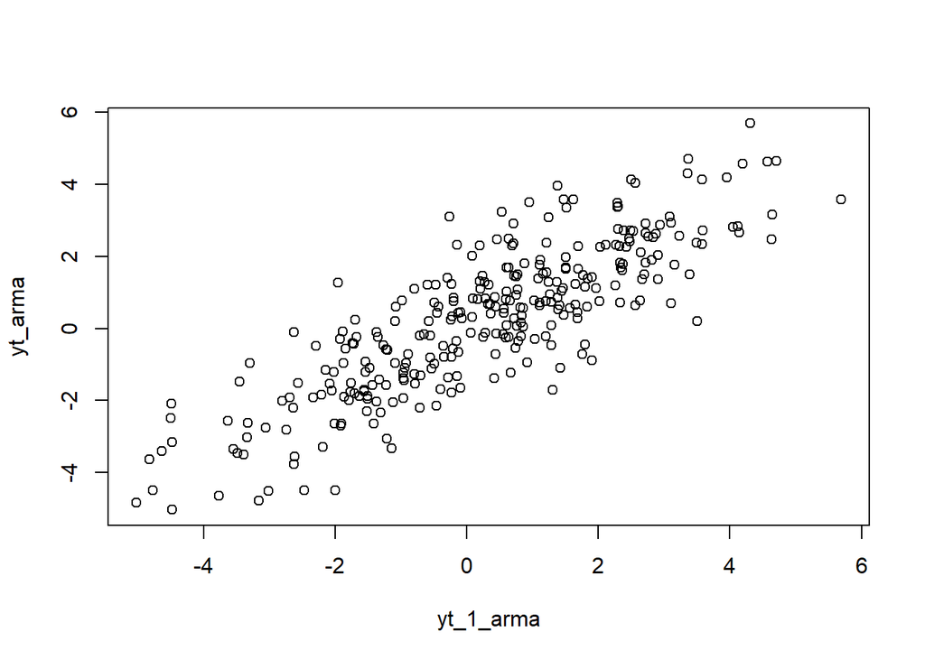

```r
plot(y=yt_arma,x=yt_1_arma)
```

```r
cor(yt_arma,yt_1_arma)
```

```
## [1] 0.8371571
```

Berdasarkan scatterplot tersebut, terlihat bahwa terdapat hubungan positif antara $Y_t$ dengan $Y_{t-1}$. Hal ini sesuai dengan teori yang ada

#### Scatterplot dan Korelasi antara $Y_t$ dengan $Y_{t-2}$

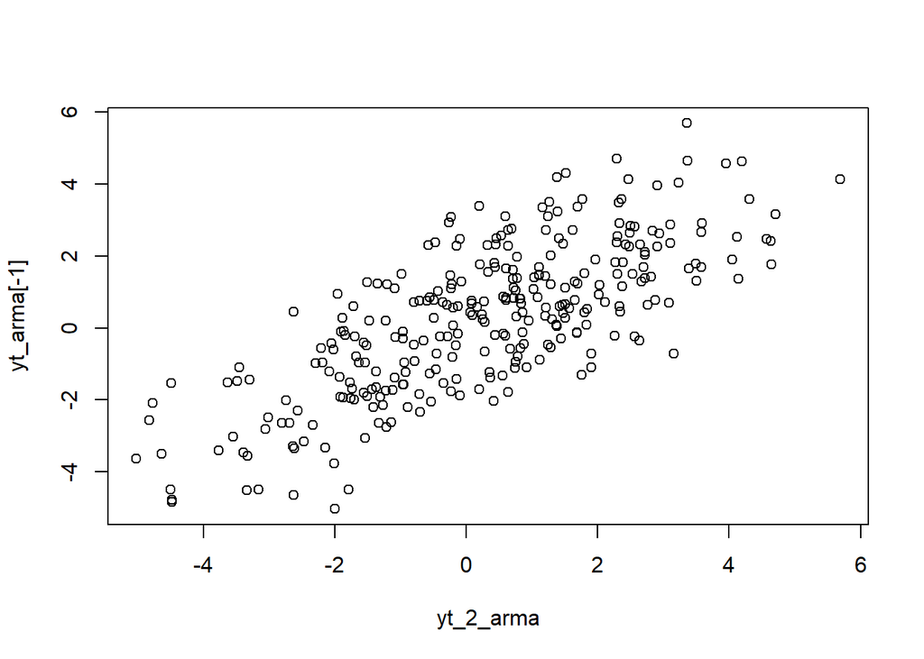

```r
plot(y=yt_arma[-1],x=yt_2_arma)
```

```r
cor(yt_arma[-1],yt_2_arma)
```

```
## [1] 0.7452241
```

#### Scatterplot dan Korelasi antara $Y_t$ dengan $Y_{t-3}$

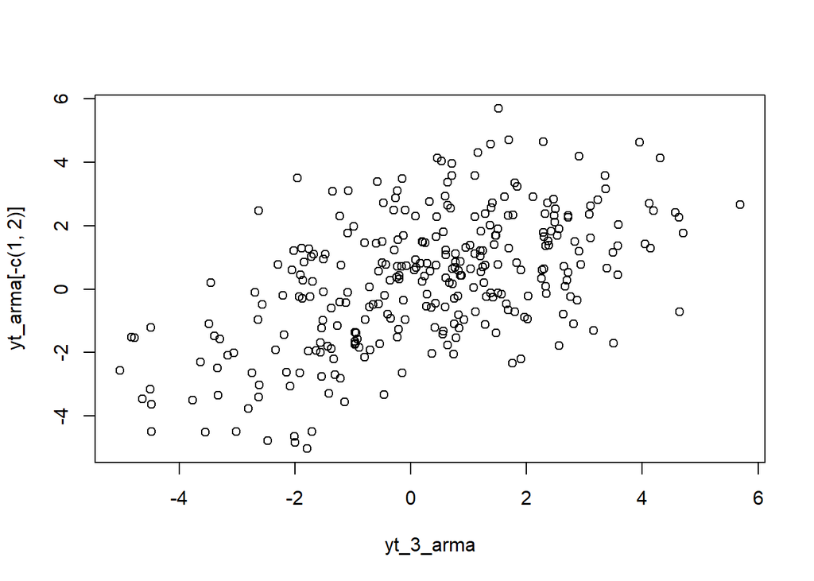

```r
plot(y=yt_arma[-c(1,2)],x=yt_3_arma)
```

```r
cor(yt_arma[-c(1,2)],yt_3_arma)
```

```
## [1] 0.5465251
```